# Airlines Passengers Satisfaction Prediction using Logistic Regression and K-Nearest Neighbor

By : Syabaruddin Malik

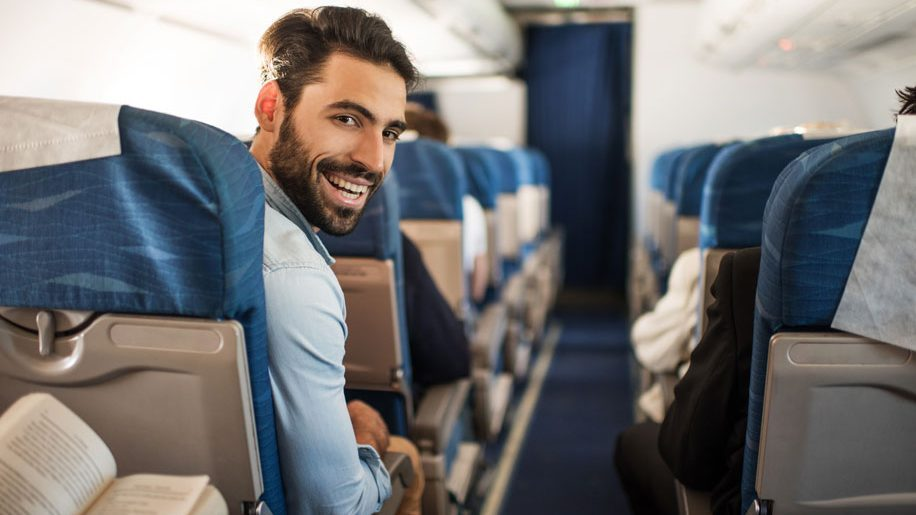

# 1 Introduction

Hello Readers! For this project, we are using a dataset from Kaggle on Airlines Customer Satisfaction using various factors. We are going to implement the Logistic Regression and K-Nearest Neighbors model for this report to predict Airlines Passengers Satisfaction.

dataset source : https://www.kaggle.com/teejmahal20/airline-passenger-satisfaction

# 2 Data Preparation

## 2.1 Library and Setup

Before we do analysis, we need to load the required library packages.

```r
library(tidyverse)
library(ggplot2)
library(class)
library(caret)
library(ggmosaic)
library(kableExtra)
library(lmtest)
library(car)
```

## 2.2 Import Data

We need the data to do the analysis. Then, we have to load the dataset

```r
airlines <- read.csv("train.csv")

head(airlines)
```

|  | X | id | Gender | Customer.Type | Age | Type.of.Travel | Class | Flight.Distance | Inflight.wifi.service | Departure.Arrival.time.convenient | Ease.of.Online.booking | Gate.location | Food.and.drink | Online.boarding | Seat.comfort | Inflight.entertainment | On.board.service | Leg.room.service | Baggage.handling | Checkin.service | Inflight.service | Cleanliness | Departure.Delay.in.Minutes | Arrival.Delay.in.Minutes | satisfaction |
| --- | --- | --- | --- | --- | --- | --- | --- | --- | --- | --- | --- | --- | --- | --- | --- | --- | --- | --- | --- | --- | --- | --- | --- | --- | --- |
| 1 | 0 | 70172 | Male | Loyal Customer | 13 | Personal Travel | Eco Plus | 460 | 3 | 4 | 3 | 1 | 5 | 3 | 5 | 5 | 4 | 3 | 4 | 4 | 5 | 5 | 25 | 18 | neutral or dissatisfied |
| 2 | 1 | 5047 | Male | disloyal Customer | 25 | Business travel | Business | 235 | 3 | 2 | 3 | 3 | 1 | 3 | 1 | 1 | 1 | 5 | 3 | 1 | 4 | 1 | 1 | 6 | neutral or dissatisfied |
| 3 | 2 | 110028 | Female | Loyal Customer | 26 | Business travel | Business | 1142 | 2 | 2 | 2 | 2 | 5 | 5 | 5 | 5 | 4 | 3 | 4 | 4 | 4 | 5 | 0 | 0 | satisfied |
| 4 | 3 | 24026 | Female | Loyal Customer | 25 | Business travel | Business | 562 | 2 | 5 | 5 | 5 | 2 | 2 | 2 | 2 | 2 | 5 | 3 | 1 | 4 | 2 | 11 | 9 | neutral or dissatisfied |
| 5 | 4 | 119299 | Male | Loyal Customer | 61 | Business travel | Business | 214 | 3 | 3 | 3 | 3 | 4 | 5 | 5 | 3 | 3 | 4 | 4 | 3 | 3 | 3 | 0 | 0 | satisfied |
| 6 | 5 | 111157 | Female | Loyal Customer | 26 | Personal Travel | Eco | 1180 | 3 | 4 | 2 | 1 | 1 | 2 | 1 | 1 | 3 | 4 | 4 | 4 | 4 | 1 | 0 | 0 | neutral or dissatisfied |

## 2.3 Data Description

To get to know more of our dataset, here is the thorough explanations about each variables:

- Gender: Gender of the passengers (Female, Male)
- Customer Type: The customer type (Loyal customer, disloyal customer)
- Age: The actual age of the passengers
- Type of Travel: Purpose of the flight of the passengers (Personal Travel, Business Travel)
- Class: Travel class in the plane of the passengers (Business, Eco, Eco Plus)
- Flight distance: The flight distance of this journey
- Inflight wifi service: Satisfaction level of the inflight wifi service (0:Not Applicable;1-5)
- Departure/Arrival time convenient: Satisfaction level of Departure/Arrival time convenient
- Ease of Online booking: Satisfaction level of online booking
- Gate location: Satisfaction level of Gate location
- Food and drink: Satisfaction level of Food and drink
- Online boarding: Satisfaction level of online boarding
- Seat comfort: Satisfaction level of Seat comfort
- Inflight entertainment: Satisfaction level of inflight entertainment
- On-board service: Satisfaction level of On-board service
- Leg room service: Satisfaction level of Leg room service
- Baggage handling: Satisfaction level of baggage handling
- Check-in service: Satisfaction level of Check-in service
- Inflight service: Satisfaction level of inflight service
- Cleanliness: Satisfaction level of Cleanliness
- Departure Delay in Minutes: Minutes delayed when departure
- Arrival Delay in Minutes: Minutes delayed when Arrival
- Satisfaction: Airline satisfaction level(Satisfaction, neutral or dissatisfaction)

# 3 Exploratory Data Analysis

## 3.1 Check Data Type

Let us check each column’s data type.

```r
glimpse(airlines)
```

```
#> Rows: 103,904
#> Columns: 25
#> $ X                                 <int> 0, 1, 2, 3, 4, 5, 6, 7, 8, 9, 10, 11~
#> $ id                                <int> 70172, 5047, 110028, 24026, 119299, ~
#> $ Gender                            <chr> "Male", "Male", "Female", "Female", ~
#> $ Customer.Type                     <chr> "Loyal Customer", "disloyal Customer~
#> $ Age                               <int> 13, 25, 26, 25, 61, 26, 47, 52, 41, ~
#> $ Type.of.Travel                    <chr> "Personal Travel", "Business travel"~
#> $ Class                             <chr> "Eco Plus", "Business", "Business", ~
#> $ Flight.Distance                   <int> 460, 235, 1142, 562, 214, 1180, 1276~
#> $ Inflight.wifi.service             <int> 3, 3, 2, 2, 3, 3, 2, 4, 1, 3, 4, 2, ~
#> $ Departure.Arrival.time.convenient <int> 4, 2, 2, 5, 3, 4, 4, 3, 2, 3, 5, 4, ~
#> $ Ease.of.Online.booking            <int> 3, 3, 2, 5, 3, 2, 2, 4, 2, 3, 5, 2, ~
#> $ Gate.location                     <int> 1, 3, 2, 5, 3, 1, 3, 4, 2, 4, 4, 2, ~
#> $ Food.and.drink                    <int> 5, 1, 5, 2, 4, 1, 2, 5, 4, 2, 2, 1, ~
#> $ Online.boarding                   <int> 3, 3, 5, 2, 5, 2, 2, 5, 3, 3, 5, 2, ~
#> $ Seat.comfort                      <int> 5, 1, 5, 2, 5, 1, 2, 5, 3, 3, 2, 1, ~
#> $ Inflight.entertainment            <int> 5, 1, 5, 2, 3, 1, 2, 5, 1, 2, 2, 1, ~
#> $ On.board.service                  <int> 4, 1, 4, 2, 3, 3, 3, 5, 1, 2, 3, 1, ~
#> $ Leg.room.service                  <int> 3, 5, 3, 5, 4, 4, 3, 5, 2, 3, 3, 2, ~
#> $ Baggage.handling                  <int> 4, 3, 4, 3, 4, 4, 4, 5, 1, 4, 5, 5, ~
#> $ Checkin.service                   <int> 4, 1, 4, 1, 3, 4, 3, 4, 4, 4, 3, 5, ~
#> $ Inflight.service                  <int> 5, 4, 4, 4, 3, 4, 5, 5, 1, 3, 5, 5, ~
#> $ Cleanliness                       <int> 5, 1, 5, 2, 3, 1, 2, 4, 2, 2, 2, 1, ~
#> $ Departure.Delay.in.Minutes        <int> 25, 1, 0, 11, 0, 0, 9, 4, 0, 0, 0, 0~
#> $ Arrival.Delay.in.Minutes          <dbl> 18, 6, 0, 9, 0, 0, 23, 0, 0, 0, 0, 0~
#> $ satisfaction                      <chr> "neutral or dissatisfied", "neutral ~
```

After we check the data type of each columns, we found that some of the columns don’t have the required data type. We need to change these columns’ data type for us to ease the analysis process. We also found that some columns needs to be dropped since these columns have no valuable informations for the analysis.To simplify our modeling, we are going to change the dissatified category into 0 and satisfied category into 1.

```r
df_airlines <- airlines %>%
  select(-X,-id) %>%
  mutate_if(is.character,as.factor) %>%
  mutate(satisfaction =
           factor(satisfaction,
                 levels = c("neutral or dissatisfied","satisfied"),
                 labels = c(0, 1)),
         Customer.Type =
           factor(Customer.Type,
                 levels = c("disloyal Customer","Loyal Customer"),
                 labels = c(0, 1)))

glimpse(df_airlines)
```

```
#> Rows: 103,904
#> Columns: 23
#> $ Gender                            <fct> Male, Male, Female, Female, Male, Fe~
#> $ Customer.Type                     <fct> 1, 0, 1, 1, 1, 1, 1, 1, 1, 0, 0, 1, ~
#> $ Age                               <int> 13, 25, 26, 25, 61, 26, 47, 52, 41, ~
#> $ Type.of.Travel                    <fct> Personal Travel, Business travel, Bu~
#> $ Class                             <fct> Eco Plus, Business, Business, Busine~
#> $ Flight.Distance                   <int> 460, 235, 1142, 562, 214, 1180, 1276~
#> $ Inflight.wifi.service             <int> 3, 3, 2, 2, 3, 3, 2, 4, 1, 3, 4, 2, ~
#> $ Departure.Arrival.time.convenient <int> 4, 2, 2, 5, 3, 4, 4, 3, 2, 3, 5, 4, ~
#> $ Ease.of.Online.booking            <int> 3, 3, 2, 5, 3, 2, 2, 4, 2, 3, 5, 2, ~
#> $ Gate.location                     <int> 1, 3, 2, 5, 3, 1, 3, 4, 2, 4, 4, 2, ~
#> $ Food.and.drink                    <int> 5, 1, 5, 2, 4, 1, 2, 5, 4, 2, 2, 1, ~
#> $ Online.boarding                   <int> 3, 3, 5, 2, 5, 2, 2, 5, 3, 3, 5, 2, ~
#> $ Seat.comfort                      <int> 5, 1, 5, 2, 5, 1, 2, 5, 3, 3, 2, 1, ~
#> $ Inflight.entertainment            <int> 5, 1, 5, 2, 3, 1, 2, 5, 1, 2, 2, 1, ~
#> $ On.board.service                  <int> 4, 1, 4, 2, 3, 3, 3, 5, 1, 2, 3, 1, ~
#> $ Leg.room.service                  <int> 3, 5, 3, 5, 4, 4, 3, 5, 2, 3, 3, 2, ~
#> $ Baggage.handling                  <int> 4, 3, 4, 3, 4, 4, 4, 5, 1, 4, 5, 5, ~
#> $ Checkin.service                   <int> 4, 1, 4, 1, 3, 4, 3, 4, 4, 4, 3, 5, ~
#> $ Inflight.service                  <int> 5, 4, 4, 4, 3, 4, 5, 5, 1, 3, 5, 5, ~
#> $ Cleanliness                       <int> 5, 1, 5, 2, 3, 1, 2, 4, 2, 2, 2, 1, ~
#> $ Departure.Delay.in.Minutes        <int> 25, 1, 0, 11, 0, 0, 9, 4, 0, 0, 0, 0~
#> $ Arrival.Delay.in.Minutes          <dbl> 18, 6, 0, 9, 0, 0, 23, 0, 0, 0, 0, 0~
#> $ satisfaction                      <fct> 0, 0, 1, 0, 1, 0, 0, 1, 0, 0, 0, 0, ~
```

All the data types are correct, we are ready to go for the next step

## 3.2 Check Missing Value

We have to check if there is any missing values in our data set

```r
colSums(is.na(df_airlines))
```

```
#>                            Gender                     Customer.Type
#>                                 0                                 0
#>                               Age                    Type.of.Travel
#>                                 0                                 0
#>                             Class                   Flight.Distance
#>                                 0                                 0
#>             Inflight.wifi.service Departure.Arrival.time.convenient
#>                                 0                                 0
#>            Ease.of.Online.booking                     Gate.location
#>                                 0                                 0
#>                    Food.and.drink                   Online.boarding
#>                                 0                                 0
#>                      Seat.comfort            Inflight.entertainment
#>                                 0                                 0
#>                  On.board.service                  Leg.room.service
#>                                 0                                 0
#>                  Baggage.handling                   Checkin.service
#>                                 0                                 0
#>                  Inflight.service                       Cleanliness
#>                                 0                                 0
#>        Departure.Delay.in.Minutes          Arrival.Delay.in.Minutes
#>                                 0                               310
#>                      satisfaction
#>                                 0
```

After we checked if there is any NA values, we found out that 310 observations are NA on the arrival_delay_in_minutes column. Here, we are going to assume that the NA value on are 0.

```r
df_airlines$Arrival.Delay.in.Minutes <-
  ifelse(is.na(df_airlines$Arrival.Delay.in.Minutes)
         , '0', df_airlines$Arrival.Delay.in.Minutes)
df_airlines$Arrival.Delay.in.Minutes <-
  as.numeric(df_airlines$Arrival.Delay.in.Minutes)

colSums(is.na(df_airlines))
```

```
#>                            Gender                     Customer.Type
#>                                 0                                 0
#>                               Age                    Type.of.Travel
#>                                 0                                 0
#>                             Class                   Flight.Distance
#>                                 0                                 0
#>             Inflight.wifi.service Departure.Arrival.time.convenient
#>                                 0                                 0
#>            Ease.of.Online.booking                     Gate.location
#>                                 0                                 0
#>                    Food.and.drink                   Online.boarding
#>                                 0                                 0
#>                      Seat.comfort            Inflight.entertainment
#>                                 0                                 0
#>                  On.board.service                  Leg.room.service
#>                                 0                                 0
#>                  Baggage.handling                   Checkin.service
#>                                 0                                 0
#>                  Inflight.service                       Cleanliness
#>                                 0                                 0
#>        Departure.Delay.in.Minutes          Arrival.Delay.in.Minutes
#>                                 0                                 0
#>                      satisfaction
#>                                 0
```

Now there are no NA in the data. Now let us go to the next step.

## 3.3 Analysis

To get to know more about our data, let us check the summary.

```r
summary(df_airlines)
```

```
#>     Gender      Customer.Type      Age                Type.of.Travel
#>  Female:52727   0:18981       Min.   : 7.00   Business travel:71655
#>  Male  :51177   1:84923       1st Qu.:27.00   Personal Travel:32249
#>                               Median :40.00
#>                               Mean   :39.38
#>                               3rd Qu.:51.00
#>                               Max.   :85.00
#>       Class       Flight.Distance Inflight.wifi.service
#>  Business:49665   Min.   :  31    Min.   :0.00
#>  Eco     :46745   1st Qu.: 414    1st Qu.:2.00
#>  Eco Plus: 7494   Median : 843    Median :3.00
#>                   Mean   :1189    Mean   :2.73
#>                   3rd Qu.:1743    3rd Qu.:4.00
#>                   Max.   :4983    Max.   :5.00
#>  Departure.Arrival.time.convenient Ease.of.Online.booking Gate.location
#>  Min.   :0.00                      Min.   :0.000          Min.   :0.000
#>  1st Qu.:2.00                      1st Qu.:2.000          1st Qu.:2.000
#>  Median :3.00                      Median :3.000          Median :3.000
#>  Mean   :3.06                      Mean   :2.757          Mean   :2.977
#>  3rd Qu.:4.00                      3rd Qu.:4.000          3rd Qu.:4.000
#>  Max.   :5.00                      Max.   :5.000          Max.   :5.000
#>  Food.and.drink  Online.boarding  Seat.comfort   Inflight.entertainment
#>  Min.   :0.000   Min.   :0.00    Min.   :0.000   Min.   :0.000
#>  1st Qu.:2.000   1st Qu.:2.00    1st Qu.:2.000   1st Qu.:2.000
#>  Median :3.000   Median :3.00    Median :4.000   Median :4.000
#>  Mean   :3.202   Mean   :3.25    Mean   :3.439   Mean   :3.358
#>  3rd Qu.:4.000   3rd Qu.:4.00    3rd Qu.:5.000   3rd Qu.:4.000
#>  Max.   :5.000   Max.   :5.00    Max.   :5.000   Max.   :5.000
#>  On.board.service Leg.room.service Baggage.handling Checkin.service
#>  Min.   :0.000    Min.   :0.000    Min.   :1.000    Min.   :0.000
#>  1st Qu.:2.000    1st Qu.:2.000    1st Qu.:3.000    1st Qu.:3.000
#>  Median :4.000    Median :4.000    Median :4.000    Median :3.000
#>  Mean   :3.382    Mean   :3.351    Mean   :3.632    Mean   :3.304
#>  3rd Qu.:4.000    3rd Qu.:4.000    3rd Qu.:5.000    3rd Qu.:4.000
#>  Max.   :5.000    Max.   :5.000    Max.   :5.000    Max.   :5.000
#>  Inflight.service  Cleanliness    Departure.Delay.in.Minutes
#>  Min.   :0.00     Min.   :0.000   Min.   :   0.00
#>  1st Qu.:3.00     1st Qu.:2.000   1st Qu.:   0.00
#>  Median :4.00     Median :3.000   Median :   0.00
#>  Mean   :3.64     Mean   :3.286   Mean   :  14.82
#>  3rd Qu.:5.00     3rd Qu.:4.000   3rd Qu.:  12.00
#>  Max.   :5.00     Max.   :5.000   Max.   :1592.00
#>  Arrival.Delay.in.Minutes satisfaction
#>  Min.   :   0.00          0:58879
#>  1st Qu.:   0.00          1:45025
#>  Median :   0.00
#>  Mean   :  15.13
#>  3rd Qu.:  13.00
#>  Max.   :1584.00
```

Below frequency data visualization for each numerical variables

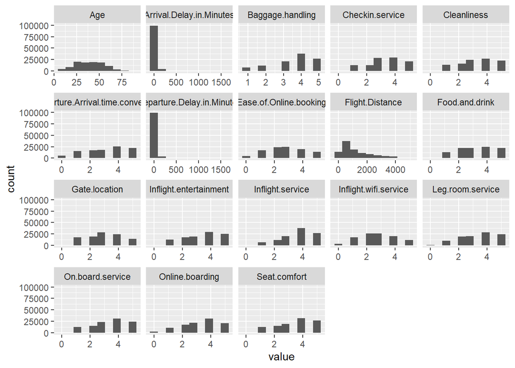

```r
ggplot(gather(df_airlines %>% select_if(is.numeric)), aes(value)) +
    geom_histogram(bins = 10) +
    facet_wrap(~key, scales = 'free_x')
```

Below frequency data visualization for each categorical variables

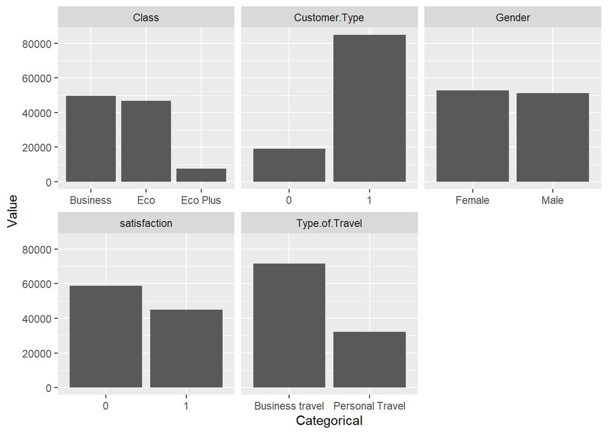

```r
ggplot(gather(df_airlines %>% select_if(is.factor)), aes(value)) +
    geom_bar(bins = 10) +
    facet_wrap(~key, scales = 'free_x') + labs(x="Categorical",
                                               y="Value")
```

# 4 Model Fitting

## 4.1 Logistic Regression

Logistic regression is a classification algorithm used to fit a regression curve, y = f (x), where y is a categorical variable. We also call the model binomial logistic regression where in cases of the Dependent Variable are more than 2 values the model are referred to as a class of multinomial logistic regression.

For our dataset, it is considered as Binomial because the target variable is 1 and 0, in which 1 is satisfied and 0 is dissatisfied.

### 4.1.1 Cross Validation

Now let us check the proportion of our target variable

```r
prop.table(table(df_airlines$satisfaction))
```

```
#>
#>         0         1
#> 0.5666673 0.4333327
```

We can say that our target variable is balance

Now we split data for train and test with proportion 0.8

```r
RNGkind(sample.kind = "Rounding")
set.seed(901)

index <- sample(nrow(df_airlines),
                nrow(df_airlines) *0.8)

airlines_train <- df_airlines[index, ]
airlines_test <- df_airlines[-index, ]
```

now let us recheck the class imbalance between data train and test

```r
prop.table(table(airlines_train$satisfaction))
```

```
#>
#>        0        1
#> 0.565752 0.434248
```

```r
prop.table(table(airlines_test$satisfaction))
```

```
#>
#>         0         1
#> 0.5703287 0.4296713
```

We can say that our target variable in both our data train and test are balance

### 4.1.2 Model

Now let us make the logistic regression model

```r
model_reg1 <- glm(satisfaction ~ ., data = df_airlines, family = "binomial")
summary(model_reg1)
```

```
#>
#> Call:
#> glm(formula = satisfaction ~ ., family = "binomial", data = df_airlines)
#>
#> Deviance Residuals:
#>     Min       1Q   Median       3Q      Max
#> -2.8452  -0.4912  -0.1752   0.3863   4.0272
#>
#> Coefficients:
#>                                      Estimate  Std. Error  z value
#> (Intercept)                       -7.86677708  0.07864177 -100.033
#> GenderMale                         0.04064051  0.01946425    2.088
#> Customer.Type1                     2.03592297  0.02990026   68.090
#> Age                               -0.00828868  0.00070967  -11.680
#> Type.of.TravelPersonal Travel     -2.72044574  0.03140894  -86.614
#> ClassEco                          -0.73656489  0.02562844  -28.740
#> ClassEco Plus                     -0.85221601  0.04146229  -20.554
#> Flight.Distance                   -0.00001715  0.00001130   -1.517
#> Inflight.wifi.service              0.39479206  0.01145636   34.461
#> Departure.Arrival.time.convenient -0.12483035  0.00820746  -15.209
#> Ease.of.Online.booking            -0.14297245  0.01132734  -12.622
#> Gate.location                      0.02930035  0.00915966    3.199
#> Food.and.drink                    -0.02760286  0.01066665   -2.588
#> Online.boarding                    0.61237478  0.01023091   59.855
#> Seat.comfort                       0.06685793  0.01116583    5.988
#> Inflight.entertainment             0.06386962  0.01424457    4.484
#> On.board.service                   0.30167518  0.01017563   29.647
#> Leg.room.service                   0.25297659  0.00852412   29.678
#> Baggage.handling                   0.13414504  0.01142242   11.744
#> Checkin.service                    0.32371984  0.00855360   37.846
#> Inflight.service                   0.12014052  0.01202728    9.989
#> Cleanliness                        0.22312375  0.01208448   18.464
#> Departure.Delay.in.Minutes         0.00413195  0.00091876    4.497
#> Arrival.Delay.in.Minutes          -0.00881618  0.00090961   -9.692
#>                                               Pr(>|z|)
#> (Intercept)                       < 0.0000000000000002 ***
#> GenderMale                                     0.03680 *
#> Customer.Type1                    < 0.0000000000000002 ***
#> Age                               < 0.0000000000000002 ***
#> Type.of.TravelPersonal Travel     < 0.0000000000000002 ***
```

[output cut: 14 more lines]

```
#> Checkin.service                   < 0.0000000000000002 ***
#> Inflight.service                  < 0.0000000000000002 ***
#> Cleanliness                       < 0.0000000000000002 ***
#> Departure.Delay.in.Minutes               0.00000688263 ***
#> Arrival.Delay.in.Minutes          < 0.0000000000000002 ***
#> ---
#> Signif. codes:  0 '***' 0.001 '**' 0.01 '*' 0.05 '.' 0.1 ' ' 1
#>
#> (Dispersion parameter for binomial family taken to be 1)
#>
#>     Null deviance: 142189  on 103903  degrees of freedom
#> Residual deviance:  69384  on 103880  degrees of freedom
#> AIC: 69432
#>
#> Number of Fisher Scoring iterations: 6
```

However let us check the multicolinearity of this model. If there is multicoleniarity in some variable, we can deselect also these variables

```r
vif(model_reg1)
```

```
#>                                        GVIF Df GVIF^(1/(2*Df))
#> Gender                             1.007211  1        1.003599
#> Customer.Type                      1.609419  1        1.268629
#> Age                                1.181080  1        1.086775
#> Type.of.Travel                     1.867260  1        1.366477
#> Class                              1.672019  2        1.137131
#> Flight.Distance                    1.356525  1        1.164699
#> Inflight.wifi.service              2.214946  1        1.488270
#> Departure.Arrival.time.convenient  1.723655  1        1.312880
#> Ease.of.Online.booking             2.589483  1        1.609187
#> Gate.location                      1.520423  1        1.233054
#> Food.and.drink                     2.007427  1        1.416837
#> Online.boarding                    1.477766  1        1.215634
#> Seat.comfort                       2.032194  1        1.425550
#> Inflight.entertainment             3.248450  1        1.802346
#> On.board.service                   1.639860  1        1.280570
#> Leg.room.service                   1.215445  1        1.102472
#> Baggage.handling                   1.827228  1        1.351750
#> Checkin.service                    1.208150  1        1.099159
#> Inflight.service                   2.010766  1        1.418015
#> Cleanliness                        2.457136  1        1.567525
#> Departure.Delay.in.Minutes        12.471198  1        3.531458
#> Arrival.Delay.in.Minutes          12.501918  1        3.535805
```

we found out that there are 2 variables Departure.Delay.in.Minutes and Arrival.Delay.in.Minutes are colinear (VIF > 10)

```r
df_airlines2 = df_airlines %>%
  select(-Departure.Delay.in.Minutes,-Arrival.Delay.in.Minutes)

model_reg2 <- glm(satisfaction ~ ., data = df_airlines2, family = "binomial")

summary(model_reg2)
```

```
#>
#> Call:
#> glm(formula = satisfaction ~ ., family = "binomial", data = df_airlines2)
#>
#> Deviance Residuals:
#>     Min       1Q   Median       3Q      Max
#> -2.8256  -0.4928  -0.1774   0.3920   4.0383
#>
#> Coefficients:
#>                                      Estimate  Std. Error  z value
#> (Intercept)                       -7.91461811  0.07834819 -101.019
#> GenderMale                         0.04007403  0.01940324    2.065
#> Customer.Type1                     2.01662055  0.02977889   67.720
#> Age                               -0.00796462  0.00070690  -11.267
#> Type.of.TravelPersonal Travel     -2.69527576  0.03128832  -86.143
#> ClassEco                          -0.74388454  0.02555284  -29.112
#> ClassEco Plus                     -0.86215655  0.04134811  -20.851
#> Flight.Distance                   -0.00001675  0.00001125   -1.489
#> Inflight.wifi.service              0.39579619  0.01141266   34.680
#> Departure.Arrival.time.convenient -0.12495144  0.00819156  -15.254
#> Ease.of.Online.booking            -0.13806445  0.01127940  -12.240
#> Gate.location                      0.02623447  0.00913712    2.871
#> Food.and.drink                    -0.02008825  0.01056405   -1.902
#> Online.boarding                    0.60897789  0.01016708   59.897
#> Seat.comfort                       0.06467007  0.01113016    5.810
#> Inflight.entertainment             0.07133195  0.01414964    5.041
#> On.board.service                   0.30147343  0.01014487   29.717
#> Leg.room.service                   0.24545014  0.00850488   28.860
#> Baggage.handling                   0.12463132  0.01139431   10.938
#> Checkin.service                    0.31914581  0.00852533   37.435
#> Inflight.service                   0.13397774  0.01196019   11.202
#> Cleanliness                        0.21137800  0.01199742   17.619
#>                                               Pr(>|z|)
#> (Intercept)                       < 0.0000000000000002 ***
#> GenderMale                                     0.03889 *
#> Customer.Type1                    < 0.0000000000000002 ***
#> Age                               < 0.0000000000000002 ***
#> Type.of.TravelPersonal Travel     < 0.0000000000000002 ***
#> ClassEco                          < 0.0000000000000002 ***
#> ClassEco Plus                     < 0.0000000000000002 ***
```

[output cut: 10 more lines]

```
#> Leg.room.service                  < 0.0000000000000002 ***
#> Baggage.handling                  < 0.0000000000000002 ***
#> Checkin.service                   < 0.0000000000000002 ***
#> Inflight.service                  < 0.0000000000000002 ***
#> Cleanliness                       < 0.0000000000000002 ***
#> ---
#> Signif. codes:  0 '***' 0.001 '**' 0.01 '*' 0.05 '.' 0.1 ' ' 1
#>
#> (Dispersion parameter for binomial family taken to be 1)
#>
#>     Null deviance: 142189  on 103903  degrees of freedom
#> Residual deviance:  69783  on 103882  degrees of freedom
#> AIC: 69827
#>
#> Number of Fisher Scoring iterations: 5
```

Now let us check the multicolnearity with this model

```r
vif(model_reg2)
```

```
#>                                       GVIF Df GVIF^(1/(2*Df))
#> Gender                            1.007173  1        1.003580
#> Customer.Type                     1.602863  1        1.266042
#> Age                               1.178991  1        1.085813
#> Type.of.Travel                    1.857451  1        1.362883
#> Class                             1.671796  2        1.137092
#> Flight.Distance                   1.356936  1        1.164876
#> Inflight.wifi.service             2.212712  1        1.487519
#> Departure.Arrival.time.convenient 1.725507  1        1.313585
#> Ease.of.Online.booking            2.584680  1        1.607694
#> Gate.location                     1.522199  1        1.233774
#> Food.and.drink                    1.980556  1        1.407322
#> Online.boarding                   1.466683  1        1.211067
#> Seat.comfort                      2.031013  1        1.425136
#> Inflight.entertainment            3.213652  1        1.792666
#> On.board.service                  1.638494  1        1.280037
#> Leg.room.service                  1.213225  1        1.101465
#> Baggage.handling                  1.822789  1        1.350107
#> Checkin.service                   1.207494  1        1.098860
#> Inflight.service                  1.998473  1        1.413673
#> Cleanliness                       2.434432  1        1.560267
```

Let us interpetrate one of coefficient and estimate so we can easily read above summary model_reg2.

```r
customer_type1 <- 2.01662055
exp(customer_type1)
```

```
#> [1] 7.512893
```

Interpretation :Customer type 1 or Loyal Customer have a probability 7.5 times more to be satisfied rather than dissatisfied.

### 4.1.3 Prediction

Now let us predict the probability of satisfaction using our test data with our model_reg2 and saved in new column named pred_result

```r
airlines_test$pred_result <- predict(object = model_reg2,
        newdata = airlines_test,
        type = "response")
```

Now classify the data in airlines_test based on pred_result and saved in new column namen pred_label

```r
airlines_test$pred_label <- ifelse(airlines_test$pred_result < 0.5 ,0, 1)
airlines_test$pred_label <- as.factor(airlines_test$pred_label)
head(airlines_test)
```

|  | Gender | Customer.Type | Age | Type.of.Travel | Class | Flight.Distance | Inflight.wifi.service | Departure.Arrival.time.convenient | Ease.of.Online.booking | Gate.location | Food.and.drink | Online.boarding | Seat.comfort | Inflight.entertainment | On.board.service | Leg.room.service | Baggage.handling | Checkin.service | Inflight.service | Cleanliness | Departure.Delay.in.Minutes | Arrival.Delay.in.Minutes | satisfaction | pred_result | pred_label |
| --- | --- | --- | --- | --- | --- | --- | --- | --- | --- | --- | --- | --- | --- | --- | --- | --- | --- | --- | --- | --- | --- | --- | --- | --- | --- |
| 1 | Male | 1 | 13 | Personal Travel | Eco Plus | 460 | 3 | 4 | 3 | 1 | 5 | 3 | 5 | 5 | 4 | 3 | 4 | 4 | 5 | 5 | 25 | 18 | 0 | 0.20159676 | 0 |
| 5 | Male | 1 | 61 | Business travel | Business | 214 | 3 | 3 | 3 | 3 | 4 | 5 | 5 | 3 | 3 | 4 | 4 | 3 | 3 | 3 | 0 | 0 | 1 | 0.88182500 | 1 |
| 6 | Female | 1 | 26 | Personal Travel | Eco | 1180 | 3 | 4 | 2 | 1 | 1 | 2 | 1 | 1 | 3 | 4 | 4 | 4 | 4 | 1 | 0 | 0 | 0 | 0.03280467 | 0 |
| 7 | Male | 1 | 47 | Personal Travel | Eco | 1276 | 2 | 4 | 2 | 3 | 2 | 2 | 2 | 2 | 3 | 3 | 4 | 3 | 5 | 2 | 9 | 23 | 0 | 0.01871983 | 0 |
| 12 | Female | 1 | 12 | Personal Travel | Eco Plus | 308 | 2 | 4 | 2 | 2 | 1 | 2 | 1 | 1 | 1 | 2 | 5 | 5 | 5 | 1 | 0 | 0 | 0 | 0.01390310 | 0 |
| 22 | Female | 1 | 17 | Personal Travel | Eco | 208 | 3 | 1 | 3 | 3 | 5 | 3 | 5 | 5 | 2 | 5 | 3 | 3 | 4 | 5 | 0 | 0 | 0 | 0.16962865 | 0 |

```r
str(airlines_test)
```

```
#> 'data.frame':    20781 obs. of  25 variables:
#>  $ Gender                           : Factor w/ 2 levels "Female","Male": 2 2 1 2 1 1 1 1 2 1 ...
#>  $ Customer.Type                    : Factor w/ 2 levels "0","1": 2 2 2 2 2 2 2 2 2 2 ...
#>  $ Age                              : int  13 61 26 47 12 17 43 36 22 35 ...
#>  $ Type.of.Travel                   : Factor w/ 2 levels "Business travel",..: 2 1 2 2 2 2 2 1 2 1 ...
#>  $ Class                            : Factor w/ 3 levels "Business","Eco",..: 3 1 2 2 3 2 2 1 2 1 ...
#>  $ Flight.Distance                  : int  460 214 1180 1276 308 208 752 3347 2342 2611 ...
#>  $ Inflight.wifi.service            : int  3 3 3 2 2 3 3 3 3 4 ...
#>  $ Departure.Arrival.time.convenient: int  4 3 4 4 4 1 5 1 2 5 ...
#>  $ Ease.of.Online.booking           : int  3 3 2 2 2 3 3 1 3 4 ...
#>  $ Gate.location                    : int  1 3 1 3 2 3 5 1 3 4 ...
#>  $ Food.and.drink                   : int  5 4 1 2 1 5 5 1 3 4 ...
#>  $ Online.boarding                  : int  3 5 2 2 2 3 4 2 3 4 ...
#>  $ Seat.comfort                     : int  5 5 1 2 1 5 5 1 1 4 ...
#>  $ Inflight.entertainment           : int  5 3 1 2 1 5 3 3 3 3 ...
#>  $ On.board.service                 : int  4 3 3 3 1 2 3 3 2 3 ...
#>  $ Leg.room.service                 : int  3 4 4 3 2 5 3 3 4 4 ...
#>  $ Baggage.handling                 : int  4 4 4 4 5 3 5 3 3 5 ...
#>  $ Checkin.service                  : int  4 3 4 3 5 3 3 2 4 4 ...
#>  $ Inflight.service                 : int  5 3 4 5 5 4 3 3 2 3 ...
#>  $ Cleanliness                      : int  5 3 1 2 1 5 4 2 3 4 ...
#>  $ Departure.Delay.in.Minutes       : int  25 0 0 9 0 0 52 18 19 109 ...
#>  $ Arrival.Delay.in.Minutes         : num  18 0 0 23 0 0 29 12 0 120 ...
#>  $ satisfaction                     : Factor w/ 2 levels "0","1": 1 2 1 1 1 1 1 1 1 2 ...
#>  $ pred_result                      : num  0.2016 0.8818 0.0328 0.0187 0.0139 ...
#>  $ pred_label                       : Factor w/ 2 levels "0","1": 1 2 1 1 1 1 1 1 1 2 ...
```

## 4.2 K-Nearest Neighbor

K-NN has its own characteristics and one of them was it is better for predictors that are numeric, therefore, in our pre-processing step here we are going to divide the categorical variables in order to make the train and test dataset.

```r
# predictor
airlines_train_x <-
  airlines_train %>% select(
    -c(
      satisfaction,
      Gender,
      Customer.Type,
      Type.of.Travel,
      Class,
      Arrival.Delay.in.Minutes ,
      Departure.Delay.in.Minutes,
      Flight.Distance
    )
  )
airlines_test_x <-
  airlines_test %>% select(
    -c(
      satisfaction,
      Gender,
      Customer.Type,
      Type.of.Travel,
      Class,
      Arrival.Delay.in.Minutes ,
      Departure.Delay.in.Minutes,
      Flight.Distance,pred_label,
      pred_result
    )
  )

# target
airlines_train_y <- airlines_train %>% select(satisfaction)
airlines_test_y <- airlines_test %>% select(satisfaction)
```

### 4.2.1 Scaling

```r
airlines_train_xs <- scale(airlines_train_x)
airlines_test_xs <- scale(airlines_test_x)

head(airlines_test_xs)
```

```
#>           Age Inflight.wifi.service Departure.Arrival.time.convenient
#> 1  -1.7509764             0.2028933                        0.61816326
#> 5   1.4318420             0.2028933                       -0.03631252
#> 6  -0.8889631             0.2028933                        0.61816326
#> 7   0.5035199            -0.5521792                        0.61816326
#> 12 -1.8172851            -0.5521792                        0.61816326
#> 22 -1.4857415             0.2028933                       -1.34526409
#>    Ease.of.Online.booking Gate.location Food.and.drink Online.boarding
#> 1               0.1665915   -1.54563447      1.3461354      -0.1859215
#> 5               0.1665915    0.01638615      0.5962013       1.2978094
#> 6              -0.5453019   -1.54563447     -1.6536008      -0.9277870
#> 7              -0.5453019    0.01638615     -0.9036667      -0.9277870
#> 12             -0.5453019   -0.76462416     -1.6536008      -0.9277870
#> 22              0.1665915    0.01638615      1.3461354      -0.1859215
#>    Seat.comfort Inflight.entertainment On.board.service Leg.room.service
#> 1      1.174215              1.2276308        0.4828480       -0.2733508
#> 5      1.174215             -0.2667543       -0.2898352        0.4858717
#> 6     -1.847158             -1.7611394       -0.2898352        0.4858717
#> 7     -1.091815             -1.0139469       -0.2898352       -0.2733508
#> 12    -1.847158             -1.7611394       -1.8352016       -1.0325733
#> 22     1.174215              1.2276308       -1.0625184        1.2450942
#>    Baggage.handling Checkin.service Inflight.service Cleanliness
#> 1         0.2991116       0.5501049        1.1598542   1.3000469
#> 5         0.2991116      -0.2394337       -0.5424503  -0.2218253
#> 6         0.2991116       0.5501049        0.3087019  -1.7436974
#> 7         0.2991116      -0.2394337        1.1598542  -0.9827613
#> 12        1.1486180       1.3396436        1.1598542  -1.7436974
#> 22       -0.5503948      -0.2394337        0.3087019   1.3000469
```

### 4.2.2 Prediction

Now let’s find the optimum K for further analysis

```r
round(sqrt(nrow(airlines_train_xs)))
```

```
#> [1] 288
```

```r
airlines_knn <- knn(train=airlines_train_xs,test=airlines_test_xs, cl= airlines_train_y$satisfaction, k=288)

head(airlines_knn)
```

```
#> [1] 0 1 0 0 0 0
#> Levels: 0 1
```